# Week 8: Social Platforms and Theory

Lecture

Mohammed Ali Sharafuddin

## Week 8 Lecture: Social Platforms and Theory

Discussion

**1 Introduction & Recall**

⏱ 10 min

Aims; quick poll on platform formats and cadence across Meta, X, YouTube, LinkedIn

Acquisition

**2 Platforms & Theory**

⏱ 30 min

Four platform environments, creative and disclosure, cadence and tone, TAM and SIP, evaluation

Practice

**3 Guided Whole-Class Discussion**

⏱ 15 min

Mini-case: choose one platform and message; state cadence and one TAM or SIP justification

Assessment

**4 Attendance & Exit Check**

⏱ 5 min

Attendance, one-minute exit check

## Module Arc

**Weeks 1–2**

Foundations and Planning

→

**Weeks 3–5**

Content and Media

→

**Weeks 6–8**

Acquisition Channels

→

**Weeks 9–12**

Relationships and Measurement

→

**Weeks 13–15**

Governance and AI

> **This closes the Acquisition Channels block.** Search finds people who are already looking. Social reaches people who came for something else entirely, and has to earn the attention before it earns the click.

## Today’s Agenda

**Six things to take into the tutorial**

1. Why theory outlasts platform tips
2. TAM: ease, usefulness, trust
3. SIP: relationship, reply quality, time
4. Four platform environments
5. Creative and disclosure; cadence and tone
6. Evaluation: reach, engagement quality, click or conversion

**The artefact you build**

A one-week social plan, six fields per post:

- Platform
- Format
- Message
- Asset
- Cadence
- Primary metric

Plus two paragraphs of rationale, one per theory.

## Why Two Theories Beat One Checklist

> Formats change. The feed algorithm is rewritten. Last year’s advice about optimal posting times becomes this year’s superstition.

**Theory ages better. It describes the person, and people change more slowly than interfaces.**

## The Technology Acceptance Model

> Adoption is driven by two beliefs: **perceived usefulness** and **perceived ease of use** (Davis, F. D., 1989). Commercial settings add a third: **trust**.

**Read all three as barriers standing between your post and the action you want.**

## Three Barriers, One Diagnosis

[interactive chart not shown]

Figure 1

**Ease shapes usefulness, as in Davis’s original model. All three converge on intention before an action follows: identify the belief that is actually weak before choosing the creative.**

## Ease: Count the Decisions

**Ease is the friction between the thumb and the outcome.**

A post asking someone to visit a website, find the shop page, choose a variant, and register an account is asking for **four decisions**. Each one loses people.

> When Reefkind moved its stockist list from a PDF link to a native map inside the post caption, the same creative and the same audience produced more shop visits. Two steps had disappeared.

## Usefulness: Worth the Attention It Costs

**A photograph of a sunscreen tube is a product shot.**

**A ninety-second clip explaining which UV filters bleach coral, and which leave it alone, is useful to a diver who buys nothing at all.**

The second one earns saves, gets sent to a dive buddy, and is still working in six months.

## Trust: The Barrier Evidence Solves

**“Reef-safe” is a claim anyone can print.**

What turns it into something a buyer will risk money on:

- A **named lab test**, dated, from an accredited testing house
- A **visible ingredient list**, readable on screen
- A **dive centre willing to be quoted** and identified

## Social Information Processing

> Early theorists predicted online relationships would stay shallow, because text strips out tone, expression, and posture. They were wrong.

**Walther showed relationships reach comparable depth online, given one extra ingredient: time** (Walther, J. B., 1992).

## Three Consequences for a Brand Account

**Relationship accumulates.** Six months of consistent presence is an asset a better-funded competitor will need six months to match.

**Reply quality carries disproportionate weight.** A comment answered in one specific, informative sentence does more relational work than three scheduled posts.

**Time is the input the theory insists on.** Cadence matters less as a number than as a signal of continued presence.

## What This Means for Your Budget

> The most common social media budget error: spending everything on production and nothing on the hours after publication.

**Reefkind’s plan reserves twenty minutes a day for replies.**

A diver asking “does this work under a 3mm wetsuit?” is a Conviction-stage buyer, and answering well in public answers it for everyone who reads the thread later.

## Four Platform Environments

> Each platform has a **dominant format**, a **cadence expectation**, and a **tone**. Those three together decide whether your creative fits, or reads as an import from somewhere else.

**Meta · X · YouTube · LinkedIn**

## Cadence and Tone: The Map

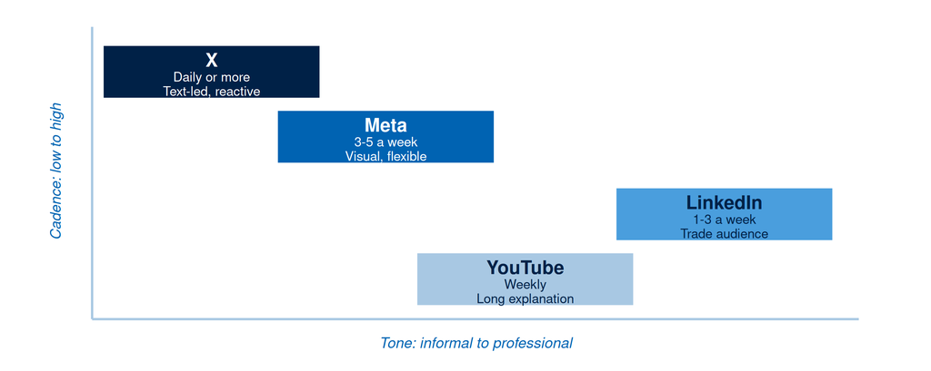

Figure 2

## The Four, Briefly

**Meta (Facebook and Instagram)** · broadest reach in this market, most format-flexible: feed, carousel, Stories, Reels. Facebook groups reach local trade.

**X** · fast, text-led, reactive. Post copy runs to 280 characters; threads extend a claim.

**YouTube** · where the long explanation lives, plus Shorts for discovery. Search-driven, so a good video keeps earning views for months.

**LinkedIn** · reaches the trade: procurement managers, dive centre owners, distributors.

## Creative and Disclosure Basics

> Two disclosure obligations apply to the work you plan this week, and the platforms enforce both.

**Paid partnership · Advertising claims**

## Disclosure: Two Obligations

**Paid partnership disclosure**

When a creator posts about your brand for payment, free product, or any other consideration, the post must be labelled. Meta and Instagram have a branded content tag; X and YouTube have equivalents; `#ad` is the written convention.

> Placed where a reader sees it **without expanding the caption**. Buried at the end of a hashtag block satisfies nobody, and platforms increasingly detect and demote it.

**Advertising disclosure**

A promoted post carries a platform-applied label. Your obligation is in the creative: claims in a paid post are advertising claims, and the evidence has to exist before the post runs.

## Two Creative Rules from the Environment

**Design for sound-off.** Most feed video is watched muted, so burned-in captions carry the argument.

**Design for the crop.** A 16:9 asset placed in a 9:16 Story loses a third of its frame. The claim belongs in the middle.

> Both rules come from how the platform is actually used, and both are checked in your tutorial submission.

## Evaluation: Three Lenses

> **Reach** · how many distinct people saw it.

> **Engagement quality** · what the reaction cost the viewer.

> **Click or conversion** · traffic that arrived, and what it did next.

**Follower count belongs to none of the three.**

## Engagement Quality: What Did It Cost?

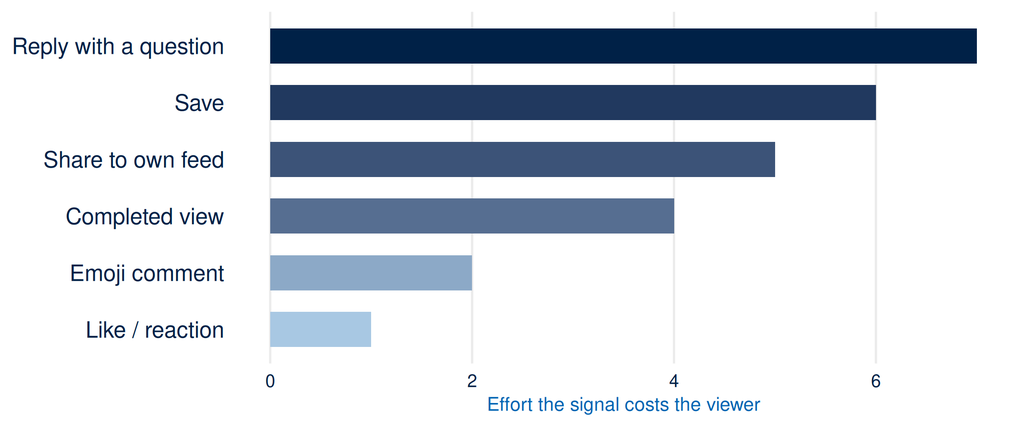

Figure 3

## Worked Example: Reefkind

> A Maldivian reef-safe mineral sunscreen brand. Two segments: **visiting divers and snorkellers** who buy on the island, and **dive centres** that stock retail.

**Canvas position: Knowledge-to-Preference transition. Blocking barrier: trust.**

## Reefkind’s One-Week Plan

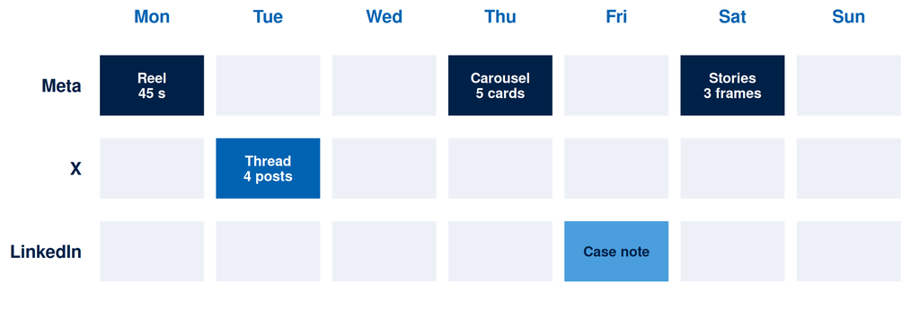

Figure 4

**Primary metric: saves on the ingredient Reel.** Reach is diagnostic; LinkedIn enquiries are the trade outcome.

## The Rationale, in Theory Terms

**TAM.** The campaign attacks the **trust** belief with third-party evidence: a dated lab certificate, a readable ingredient list, a named dive centre. Ease is handled as a landing-page fix that never has to carry the campaign.

**SIP.** The campaign invests in reply speed because relational depth accumulates through exchange over time, and no single well-funded asset shortcuts it.

> Notice what this avoids saying: that the content is engaging or high quality. It names a **mechanism** and commits to an **observable consequence**.

## Guided Discussion: The Mini-Case

> **Fifteen minutes, whole class.**

**Choose one platform and one message. State your cadence, and give one TAM or SIP justification for it.**

## Mini-Case: Work It Through

**The situation.** A Malé café roastery sells bags of locally roasted beans. It has 800 Instagram followers, one part-time person on social, and a claim that its beans are roasted the same week they are sold.

1. **Which barrier is blocking?** Ease, usefulness, or trust. Defend it in one sentence.
2. **One platform, one message.** Name both.
3. **Cadence.** How often, and can one part-time person staff the replies?
4. **The justification.** One sentence citing TAM or SIP by name.

## The AI Protocol for Week 8

> AI helps with two parts of this week’s work, and should stay out of a third.

## AI: Permitted and Prohibited

| Use AI for this | Keep AI out of this |
| --- | --- |
| Pressure-testing your rationale: ask it to flag any sentence asserting quality without naming a mechanism | Inventing testimonials, quotes, or named partners |
| Generating caption variants once message and format are fixed | Reporting engagement benchmarks with no documented source |
| Suggesting reply wording for a difficult comment, which you then rewrite | Describing what a competitor’s live ads currently say |
| Checking a plan for cadence you can actually staff | Producing the lab evidence your trust claim depends on |

> **Prompt log requirement:** at least two prompts, with the output received and the change you made. A pack with AI-assisted captions and no log is returned for resubmission.

## Exit Check

> **One minute. Write one theory-anchored action you will try next week.**

**The form:** name the theory, name the action, name what you expect to observe.

*Worked example:* “SIP. I will answer every comment within one hour on posting day for two weeks. I expect the number of replies carrying a question to rise, because earlier answers show the account is worth asking.”

## References

Davis, F. D. (1989). [Perceived usefulness, perceived ease of use, and user acceptance of information technology](https://doi.org/10.2307/249008). MIS Quarterly.

Walther, J. B. (1992). [Interpersonal effects in computer-mediated interaction: A relational perspective](https://doi.org/10.1177/009365092019001003). Communication Research.